# DebugUself

自怼圈

190413 2042

# 又

## 自怼…

> 圈?

> > 小密圈

## 自述

- who?
- where?
- why?

# 寸

## rhythm

[figure not shown]

[figure not shown]

## 知行合一

## 习惯

> 替代意志

## 节奏

> rhythm

## daily

> 嗯哼
- 固定时间
- 解决问题
- 持续记录
- 认真交流

## 环境

> github -> 用之, 弗学
- Issue -> 发问/起/记录/…
- Wiki -> 交付/沉淀/复用/..
- repo. -> 追踪/协同/原稿/…
- Slack -> 日常嗯哼/提醒
- ggroups -> 异步嗯哼/提醒/发布/通知
- 微信群 -> …

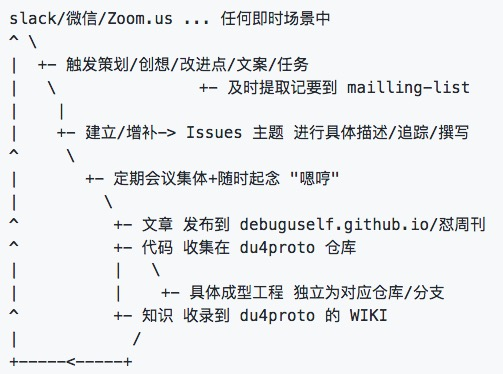

## weekly

> 嗯哼

## 周六

> 2042 zoom.us
- 破冰
- 单口/内课/…
- 当周简报
- 怼务

## 周一

> 2042 周刊发布
- 轮值
- 主编 -> DAMA
- 责编 -> 全体
- 撰稿 -> 日常 [#634](https://github.com/DebugUself/du4proto/issues/634)

## 怼周刊

> [du.101.camp/duw](https://du.101.camp/duw/)

## 怼杂记

> du.101.camp

团体 blogging

## 怼地图

> du.101.camp/map

?图谱索引

## 怼凭证

> du.101.camp/pow
- ?怂怼累计
- du.101.camp/pow/zoomquiet

# 心

## 醉点

> 明明能, 就不能

## 视而不见

> (￣▽￣)

## MVP

## 常设作品

> 入怼必须参与的作品任务
- 时间账单
- 怼周刊投稿
  - 怼周会纪要

## 公有作品

> 义务/轮值的日常作品/任务
- 怼周刊编辑/发布
- 怼周会主持
- 怼圈招新/文宣
- 怼圈运营工具箱:
  - st
  - pub

## 专属作品

> 原创/激发的3有作品
- aTL4dama
- YHDutySchedule 排班小程序
- music ~ Zoe 音乐探索
- ? Kaggle 刷题帮

## 蟒怼

> DebugUself101camp

[figure not shown]

[figure not shown]

# (￣▽￣)

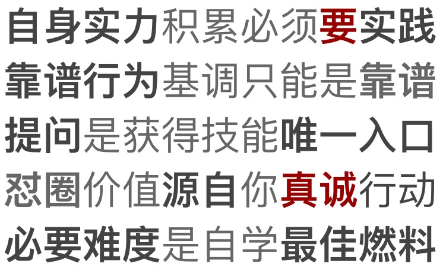

嗯哼

## slides

slides.101.camp/duw104.html

## 是也乎

- 190413 ++mapping
  - 1754 +slides link
- 190411 init.